# Praca domowa 2

Olga Kachniewska

## Dane

Dane wykorzystane w Pracy domowej 2 są związane z kampaniami marketingu bezpośredniego portugalskiej instytucji bankowej. Kampanie marketingowe opierały się na rozmowach telefonicznych. Często wymagany był więcej niż jeden kontakt z tym samym klientem, aby uzyskać dostęp do tego, czy produkt (lokata bankowa) zostanie (lub nie) subskrybowany. Opis wszystkich kolumn znajduje się również w pliku `README.md`.

#### Dane klienta banku

| Zmienna | Opis |
| --- | --- |
| **age** | wiek |
| **job** : admin., unknown, unemployed, management, housemaid, entrepreneur, student, blue-collar, self-employed, retired, technician, services | administrator, nieznany, bezrobotny, kierownictwo, pokojówka, przedsiębiorca, student, pracownik fizyczny, samozatrudniony, emeryt, technik, usługi |
| **marital** : married, divorced, single; note: divorced means divorced or widowed) | żonaty/zamężna, rozwiedzion_, kawaler/panna; uwaga: rozwiedzion_ oznacza rozwiedzion_ lub owdowiał_ |
| **education** : unknown, secondary, primary, tertiary | nieznane, średnie, podstawowe, wyższe |
| **default** : yes, no | czy kredyt jest niespłacany : tak, nie |
| **balance** : average yearly balance, in euros | średnie roczne saldo w euro |
| **housing** : has housing loan? yes, no | czy posiada kredyt mieszkaniowy? tak, nie |
| **loan** : has personal loan? yes, no | ma pożyczkę osobistą? tak, nie |

#### Dane związane z ostatnim kontaktem w bieżącej kampanii

| Zmienna | Opis |
| --- | --- |
| **contact** : unknown, telephone, cellular | nieznany, telefon, komórkowy |
| **day** : last contact day of the month | dzień miesiąca ostatniego kontaktu |
| **month** : last contact month of year, jan, feb, mar, …, nov, dec | miesiąc ostatniego kontaktu w roku, styczeń, luty, marzec, …, listopad, grudzień |
| **duration** : last contact duration, in seconds | czas trwania ostatniego kontaktu w sekundach |

## Zadanie 1

Weźmy pod uwagę zawody (`job`) klientów banku. Który zawód zacząco wyróżnia się w posiadaniu kredytu mieszkaniowego lub pożyczki osobistej?

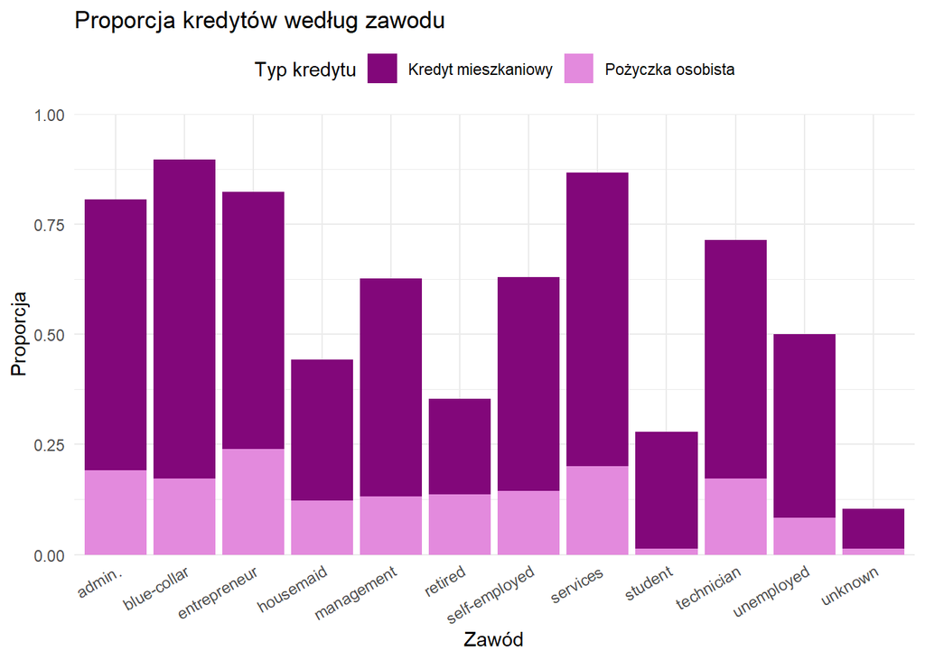

```r
# Tu umieść kod do wygenerowania odpowiedzi do zadania.

zad1 <- df %>%
  group_by(job) %>%
  summarise(
    prop_housing = mean(housing == "yes", na.rm = TRUE),
    prop_loan = mean(loan == "yes", na.rm = TRUE)
  ) %>%
  tidyr::pivot_longer(cols = c(prop_housing, prop_loan),
                      names_to = "loan_type",
                      values_to = "proportion")

ggplot(zad1, aes(x = job, y = proportion, fill = loan_type)) +
  geom_bar(stat = "identity") +
  scale_y_continuous(limits = c(0, 1), expand = c(0, 0)) +
  theme_minimal() +
  theme(axis.text.x = element_text(angle = 30, hjust = 1),
        legend.position = "top") +
  scale_fill_manual(values = c("#82077a", "#e38add"),
                    labels = c("Kredyt mieszkaniowy", "Pożyczka osobista")) +
  labs(title = "Proporcja kredytów według zawodu",
       x = "Zawód", y = "Proporcja", fill = "Typ kredytu")
```

**Komentarz:** Proporcje kredytów w poszczególnych słupkach sumarycznie reprezentuje wysokość słupka (“lub” sugeruje, że warto podkreślić, która grupa posiada najwięcej kredytów patrząc na obie opcje łącznie). Typy kredytu reprezentowane są kolorami, co podkreśla dyspropocje między popularnością występowania danego typu zadłużenia w grupach.

## Zadanie 2

Wybierając klientów, którzy mają nieznany sposób kontaktu (`contact`). Jak rozkłada się ich wiek w podziale na status związku?

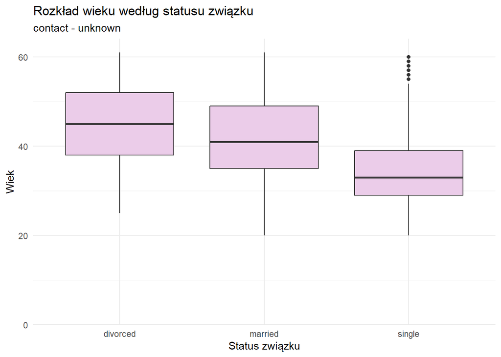

```r
# Tu umieść kod do wygenerowania odpowiedzi do zadania.
zad2 <- df %>%
  filter(contact == "unknown")

ggplot(zad2, aes(x = marital, y = age)) +
  geom_boxplot(fill = "#ebcce9") +
  scale_y_continuous(limits = c(0, max(zad2$age, na.rm = TRUE) * 1.05),
                     expand = c(0, 0)) +
  theme_minimal() +
  labs(title = "Rozkład wieku według statusu związku ",
       subtitle = "contact - unknown",
       x = "Status związku", y = "Wiek") +
  theme(legend.position = "none")
```

**Komentarz:** Rozkład wieku najlpeiej pokazać w postaci boxplotów co udziela najwięcej informacji prostej do porównania formie, a zakres wiekowy jest rozrzeszony, aby wykresy nie wydawały się ucięte na górnej granicy zakresu danych.

## Zadanie 3

Jaka jest różnica pomiędzy średnim rocznym saldem w euro w zależności od wykształcenia i tego czy kredyt jest niespłacany?

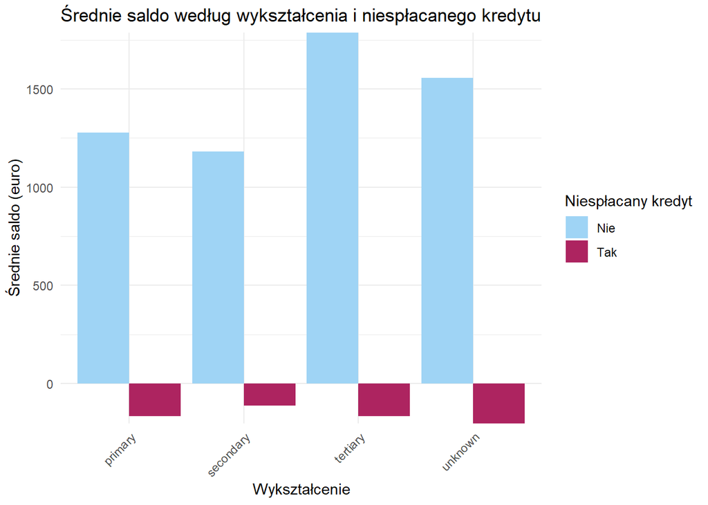

```r
# Tu umieść kod do wygenerowania odpowiedzi do zadania.
zad3 <- df %>%
  group_by(education, default) %>%
  summarise(mean_balance = mean(balance, na.rm = TRUE), .groups = "drop")

ggplot(zad3, aes(x = education, y = mean_balance, fill = default)) +
  geom_bar(stat = "identity", position = "dodge") +
  scale_y_continuous(expand = c(0, 0)) +  # Słupki od 0
  theme_minimal() +
  scale_fill_manual(values = c("#9fd4f5", "#ad2460"),
                    labels = c("Nie", "Tak")) +
  labs(title = "Średnie saldo według wykształcenia i niespłacanego kredytu",
       x = "Wykształcenie", y = "Średnie saldo (euro)", fill = "Niespłacany kredyt") +
  theme(axis.text.x = element_text(angle = 45, hjust = 1))
```

**Komentarz:** Wykres słupkowy porównuje średnie saldo dla każdego poziomu wykształcenia w podziale na status niespłacanego kredytu. Różnice są widoczne w wysokości słupków obok siebie. (nie mam pewności, czy kolorowanie wykresu nie jest błędne w przypadku, gdy kredyt niespłacany jest ujemny na osi, ale wtedy informacja o tym, że ujemna wartość to niespłacany kredyt byłaby zawarta jako komentarz w innej formie więc zostawiłam taką wersję)

## Zadanie 4

Czy dzień i miesiąc kontaktu z klientem ma wpływ na średni czas trwania rozmowy w stosunku do średniego czasu trwania rozmowy?

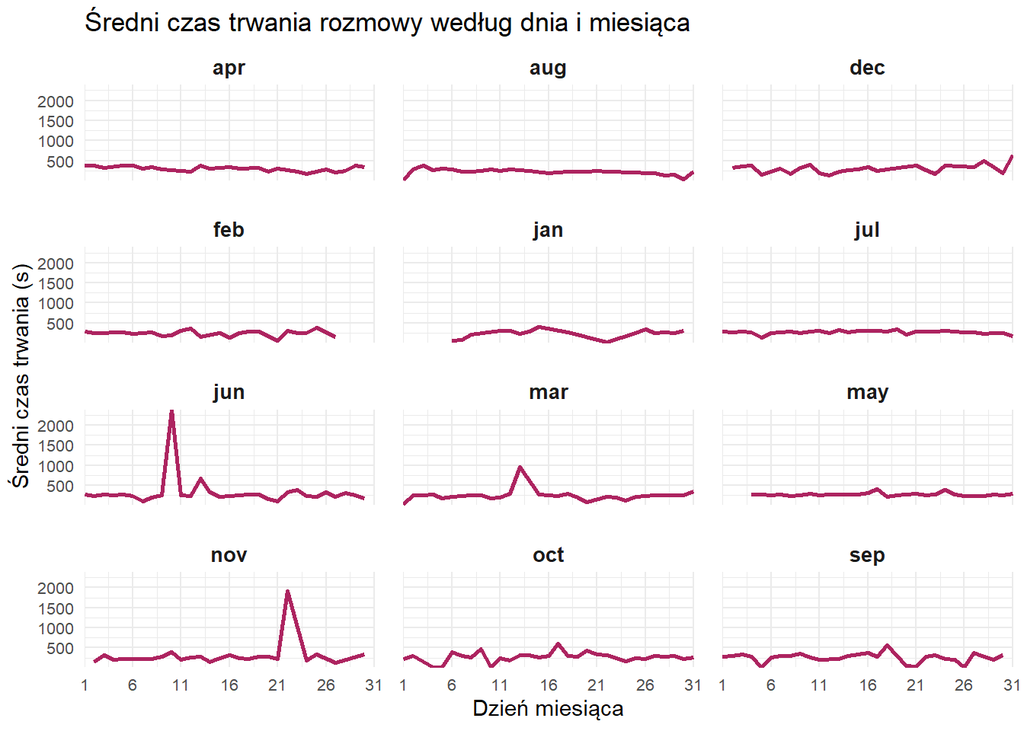

```r
# Tu umieść kod do wygenerowania odpowiedzi do zadania.

zad4 <- df %>%
  group_by(day, month) %>%
  summarise(mean_duration = mean(duration, na.rm = TRUE), .groups = "drop")

ggplot(zad4, aes(x = day, y = mean_duration)) +
  geom_line(linewidth = 1, color = "#ad2460") +
  facet_wrap(~month, nrow = 4, ncol = 3) +
  scale_x_continuous(breaks = seq(1, 31, by = 5), expand = c(0, 0)) +
  scale_y_continuous(expand = c(0, 0)) +
  theme_minimal() +
  labs(title = "Średni czas trwania rozmowy według dnia i miesiąca",
       x = "Dzień miesiąca", y = "Średni czas trwania (s)") +
  theme(
    strip.text = element_text(size = 10, face = "bold"),
    axis.text = element_text(size = 8),
    panel.spacing = unit(1, "lines")
  )
```

**Komentarz:** Aby wykres dla każdego miesiące był czytelny zostały one rozdzielone w formie siatki, a jednocześnie każdy z nich jest wyskalowany w ten sam sposób, aby porównywanie danych między miesiącami nie było zbyt skomplikowane

## Zadanie 5

Czy jest zależnośc pomiędzy wiekiem klientów a ich średnim rocznym saldzie w euro w podziale na stopień wykształcenia?

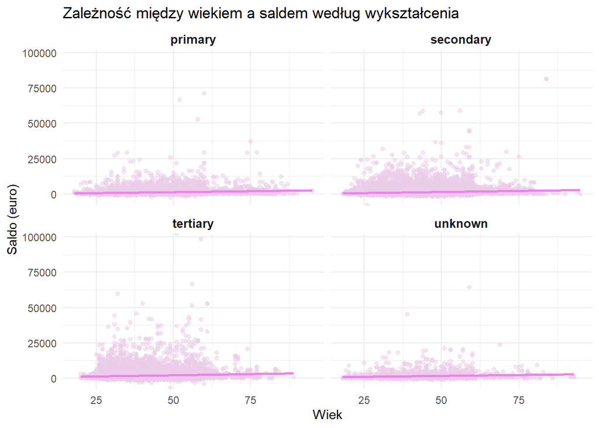

```r
# Tu umieść kod do wygenerowania odpowiedzi do zadania.
ggplot(df, aes(x = age, y = balance)) +
  geom_point(alpha = 0.5, color = "#ebcce9") +
  geom_smooth(method = "lm", se = FALSE, color = "violet") +
  facet_wrap(~education, ncol = 2) +
  scale_y_continuous(expand = c(0, 0)) +
  theme_minimal() +
  labs(title = "Zależność między wiekiem a saldem według wykształcenia",
       x = "Wiek", y = "Saldo (euro)") +
  theme(strip.text = element_text(size = 10, face = "bold"),
        legend.position = "none")
```

## Zadanie 6

Rozważmy osoby, które są bezrobotne albo ich zawód jest nieznany. Czy procent osób, które są bezrobotne i nie spłacają kredytu jest większy od procenta osób o nieznanym zawodzie i nie spłacanym kredycie? Jaki typ kredytu jest (przez te osoby) najczęściej niespłacany?

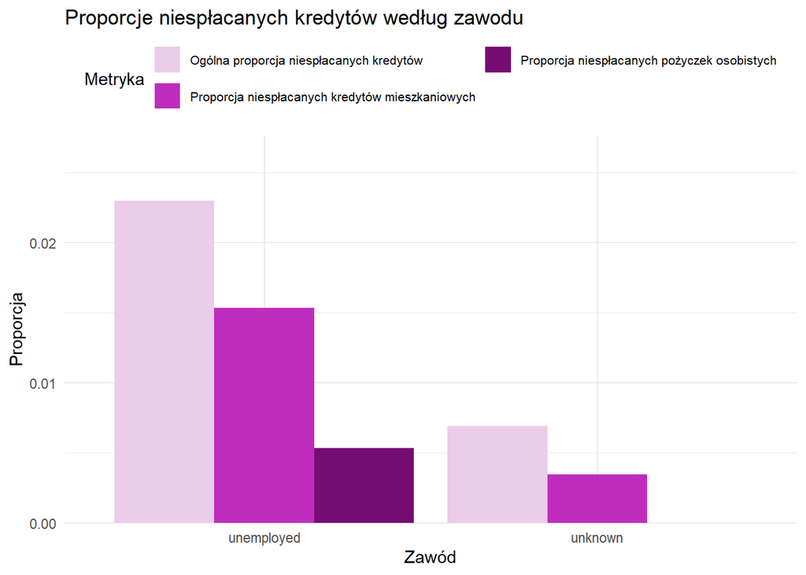

```r
# Tu umieść kod do wygenerowania odpowiedzi do zadania.
zad6 <- df %>%
  filter(job %in% c("unemployed", "unknown")) %>%
  group_by(job) %>%
  summarise(
    prop_default = mean(default == "yes", na.rm = TRUE),
    prop_housing_default = mean(housing == "yes" & default == "yes", na.rm = TRUE),
    prop_loan_default = mean(loan == "yes" & default == "yes", na.rm = TRUE),
    n = n()
  )

zad6_long <- zad6 %>%
  tidyr::pivot_longer(cols = c(prop_default, prop_housing_default, prop_loan_default),
                      names_to = "metric",
                      values_to = "proportion") %>%
  mutate(metric = factor(metric,
                         levels = c("prop_default", "prop_housing_default", "prop_loan_default"),
                         labels = c("Ogólna proporcja niespłacanych kredytów",
                                    "Proporcja niespłacanych kredytów mieszkaniowych",
                                    "Proporcja niespłacanych pożyczek osobistych")))

# Wykres: Wszystkie proporcje na jednym wykresie
ggplot(zad6_long, aes(x = job, y = proportion, fill = metric)) +
  geom_bar(stat = "identity", position = "dodge") +
  scale_y_continuous(limits = c(0, max(zad6_long$proportion) * 1.2), expand = c(0, 0)) +  # Oś Y od 0
  theme_minimal() +
  scale_fill_manual(values = c("#ebcce9", "#bf2cbd", "#750c74")) +
  labs(title = "Proporcje niespłacanych kredytów według zawodu",
       x = "Zawód", y = "Proporcja", fill = "Metryka") +
  theme(legend.position = "top",
        legend.text = element_text(size = 8)) +
  guides(fill = guide_legend(nrow = 2))
```

**Komentarz:** Każdy ze słupków reprezentuje inne proporcje związane z niespłacanymi kredytami dla określonych grup zawodowych